# ISYE6414 - Midterm Exam 1 - Open Book Section (R) - Part 2

## Instructions

This R Markdown file includes the questions, the empty code chunk sections for your code, and the text blocks for your responses. Answer the questions below by completing this R Markdown file. You may make slight adjustments to get the file to knit/convert but otherwise keep the formatting the same. Once you’ve finished answering the questions, submit your responses in a single knitted file as *HTML* only.

There are 13 questions total, each worth between 3-8.5 points. Partial credit may be given if your code is correct but your conclusion is incorrect or vice versa.

*Next Steps:*

1. Save this .Rmd file in your R working directory - the same directory where you will download the “datafull.csv” data file into. Having both files in the same directory will help in reading the .csv file.
2. Read the question and create the R code necessary within the code chunk section immediately below each question. Knitting this file will generate the output and insert it into the section below the code chunk.
3. Type your answer to the questions in the text block provided immediately after the response prompt.
4. Once you’ve finished answering all questions, knit this file and submit the knitted file as *HTML* on Canvas.

### Mock Example Question

This will be the exam question - each question is already copied from Canvas and inserted into individual text blocks below, *you do not need to copy/paste the questions from the online Canvas exam.*

```r
# Example code chunk area. Enter your code below the comment`
```

**Mock Response to Example Question**: This is the section where you type your written answers to the question. Depending on the question asked, your typed response may be a number, a list of variables, a few sentences, or a combination of these elements.

**Ready? Let’s begin. We wish you the best of luck!**

**Recommended Packages**

```r
library(car)
```

```r
library(ggplot2)
```

## house repair cost Data Analysis

For this exam, you will be building a model to predict the repair cost of roofs (*repaircost*).

The “datafull.csv” data set consists of the following variables:

- *repaircost*: repair cost of the house
- *rooftype*: roof type of the house
- *year*: year of the house
- *flood_status*: no flood or flood insurance
- *homevalue*: home value of the house
- *flooring*: flooring of the house
- *residents*: number of previous residents of the house

Read the data and answer the questions below. Assume a significance threshold of 0.05 for hypothesis tests unless stated otherwise.

```r
# Read the data set
houses = read.csv('datafull.csv', header=TRUE)
#Set rooftype and flood_status as categorical
houses$rooftype<-as.factor(houses$rooftype)
houses$flood_status<-as.factor(houses$flood_status)
head(houses)
```

```
##   repaircost rooftype year flood_status homevalue flooring residents
## 1       6300   aframe 2008     no flood    274117        6         3
## 2       2899   barrel 2011     no flood    190552       10         2
## 3       5350     bell 2018     no flood     39590        3         1
## 4      25000   barrel 2014     no flood     64146        4         1
## 5      27700      box 2018     no flood      6654        3         1
## 6       5700     bell 2018     no flood     45561        7         1
```

**Note:** For all of the following questions, treat all variables as quantitative variables except for *rooftype*, and *flood_status*. They have already been converted to categorical variables in the above code.

### Question 1 - 5pts

Create an ANOVA model, called **anovamodel**, to compare the mean house repair cost (*repaircost*) among the different house roof types (*rooftype*). Display the corresponding ANOVA table.

1. Identify the value of the mean squared error (MSE) from the ANOVA table.
2. Provide the formula that is used to calculate the MSE in the table, and clearly explain what this quantity represents in the context of ANOVA.

```r
#Code to create ANOVA model...
anovamodel <- aov(houses$repaircost ~ houses$rooftype)

summary(anovamodel)
```

```
##                   Df    Sum Sq   Mean Sq F value Pr(>F)
## houses$rooftype   27 4.412e+10 1.634e+09   12.52 <2e-16 ***
## Residuals       2471 3.226e+11 1.305e+08
## ---
## Signif. codes:  0 '***' 0.001 '**' 0.01 '*' 0.05 '.' 0.1 ' ' 1
```

**Response to Question 1A**: 1.305e+08  
In the context of this problem, MSE represents the mean squared error is also pooled variance estimator, which is used to compare means from the different populations assuming that the variance is the same across all such populations. MSE is used to measure the within-group variability.  
**Response to Question 1B**:

**Formula**: A quick and easy way to calculate MSE is to calculate this = (SSE/Df) **Explanation**: The interpretation in the context of ANOVA, as mentioned before, is that this is a measure to calculate the within-group variability when testing for equal means and hence used as the pooled variance estimator.

### Question 2 - 4pts

1. What can you conclude from the ANOVA table with respect to the test of equal means at a significance level of 0.05 (FAIL TO REJECT or REJECT the null hypothesis)? Explain your answer using the values from the ANOVA Table.
2. Given your answer in part A, explain what this conclusion means in the context of the house data analysis problem.

**Response to Question 2A**: We see that the p value is much much less than the siginificance level provided at 0.05, hence we rightfully REJECT the null hypothesis.

**Response to Question 2B**:  
Given that we REJECT the null hypothesis, which states that all groups or categories have equal means, we can conclude that at least 1 of the means we have is statistically significant different mean.

### Question 3 - 5.5 pts

Conduct a pairwise comparison of the mean *repaircost* for the different *rooftypes* using the Tukey method. Use a **90%** confidence level for this comparison.

1. According to the pairwise comparison, are the means of *jerkinhead* and *hexagonal* plausibly equal? Explain how you came to your conclusion. Note: you can use Control + F to search the printed output easily.
2. Provide an interpretation of “diff” in the context of the repaircost between *jerkinhead* and *hexagonal*. *(Note: provide this interpretation regardless of the means being statistically significantly different/equal)*

```r
# Code to create pairwise-comparison...
TukeyHSD(anovamodel, conf.level = 0.90)
```

```
##   Tukey multiple comparisons of means
##     90% family-wise confidence level
##
## Fit: aov(formula = houses$repaircost ~ houses$rooftype)
##
## $`houses$rooftype`
##                                 diff           lwr          upr     p adj
## barrel-aframe            15366.88826  -24653.86486  55387.64138 0.9999486
## bell-aframe              11481.98843  -28568.84661  51532.82346 0.9999999
## box-aframe               12369.95286  -27701.89851  52441.80423 0.9999994
## butterfly-aframe          4357.38095  -36120.62250  44835.38440 1.0000000
## clerestory-aframe         7386.11111  -33714.66742  48486.88965 1.0000000
## combination-aframe        4823.84615  -36690.84794  46338.54025 1.0000000
## conical-aframe           13415.76923  -28098.92487  54930.46333 0.9999984
## crosshipped-aframe        6798.33333  -34839.73308  48436.39975 1.0000000
## curved-aframe            22404.00000  -19553.13673  64361.13673 0.9878575
## dome-aframe               4633.83333  -36032.00409  45299.67075 1.0000000
## dormer-aframe            18641.00000  -23316.13673  60598.13673 0.9992762
## dropped-aframe           -1096.80000  -42413.33214  40219.73214 1.0000000
## dutch-aframe              1700.00000  -47295.37996  50695.37996 1.0000000
## flat-aframe               -172.50000  -41810.56642  41465.56642 1.0000000
## gable-aframe             -3334.00000  -47156.80007  40488.80007 1.0000000
## gambrel-aframe           -3500.00000  -60074.99162  53074.99162 1.0000000
## hexagonal-aframe           966.66667  -45226.62056  47159.95389 1.0000000
## hip-aframe               48380.00000   -8194.99162 104954.99162 0.3599805
## jerkinhead-aframe         7681.25000  -37045.20803  52407.70803 1.0000000
## mansard-aframe           26920.00000  -22075.37996  75915.37996 0.9822613
## monitor-aframe            5765.82051  -34302.79829  45834.43932 1.0000000
## mshaped-aframe           11850.00000  -37145.37996  60845.37996 1.0000000
## pyramid-aframe           22600.00000  -22126.45803  67326.45803 0.9944318
## saltbox-aframe           24000.00000  -32574.99162  80574.99162 0.9996757
## sawtooth-aframe          -5900.00000  -50626.45803  38826.45803 1.0000000
## shed-aframe               4750.00000  -51824.99162  61324.99162 1.0000000
## vault-aframe             20097.05882  -21067.29404  61261.41169 0.9966750
## bell-barrel              -3884.89983   -6121.05506  -1648.74460 0.0000005
## box-barrel               -2996.93540   -5582.33203   -411.53876 0.0146148
## butterfly-barrel        -11009.50731  -17286.43065  -4732.58396 0.0000004
## clerestory-barrel        -7980.77715  -17478.40841   1516.85412 0.3987007
## combination-barrel      -10543.04211  -21696.55409    610.46988 0.1719491
## conical-barrel           -1951.11903  -13104.63101   9202.39295 1.0000000
```

[output cut: 330 more lines]

```
## pyramid-mshaped          10750.00000  -23894.96542  45394.96542 0.9999994
## saltbox-mshaped          12150.00000  -36845.37996  61145.37996 1.0000000
## sawtooth-mshaped        -17750.00000  -52394.96542  16894.96542 0.9931905
## shed-mshaped             -7100.00000  -56095.37996  41895.37996 1.0000000
## vault-mshaped             8247.05882  -21658.15021  38152.26786 1.0000000
## saltbox-pyramid           1400.00000  -43326.45803  46126.45803 1.0000000
## sawtooth-pyramid        -28500.00000  -56787.49581   -212.50419 0.0923569
## shed-pyramid            -17850.00000  -62576.45803  26876.45803 0.9998933
## vault-pyramid            -2502.94118  -24734.23259  19728.35023 1.0000000
## sawtooth-saltbox        -29900.00000  -74626.45803  14826.45803 0.8512215
## shed-saltbox            -19250.00000  -75824.99162  37324.99162 0.9999954
## vault-saltbox            -3902.94118  -45067.29404  37261.41169 1.0000000
## shed-sawtooth            10650.00000  -34076.45803  55376.45803 1.0000000
## vault-sawtooth           25997.05882    3765.76741  48228.35023 0.0127151
## vault-shed               15347.05882  -25817.29404  56511.41169 0.9999710
```

**Response to Question 3A**:  
Yes, we can say that the means of *jerkinhead* and *hexagonal* plausibly equal - if we notice the confidence interval, we will see that 0 is contained in the interval and the p-value is 1. This means that these two variables can have the same mean as the confidence interval of their differences contains 0. As also supported by the p-value, the difference is not that statistically significant.  
**Response to Question 3B**:  
The diff term means that the mean value jump in jerkinhead mean keeping the hexagonal mean fixed.

### Question 4 - 8.5 pts

Perform a residual analysis on the ANOVA model (**anovamodel**). State whether each of the three ANOVA model assumptions holds and why you came to the conclusion.

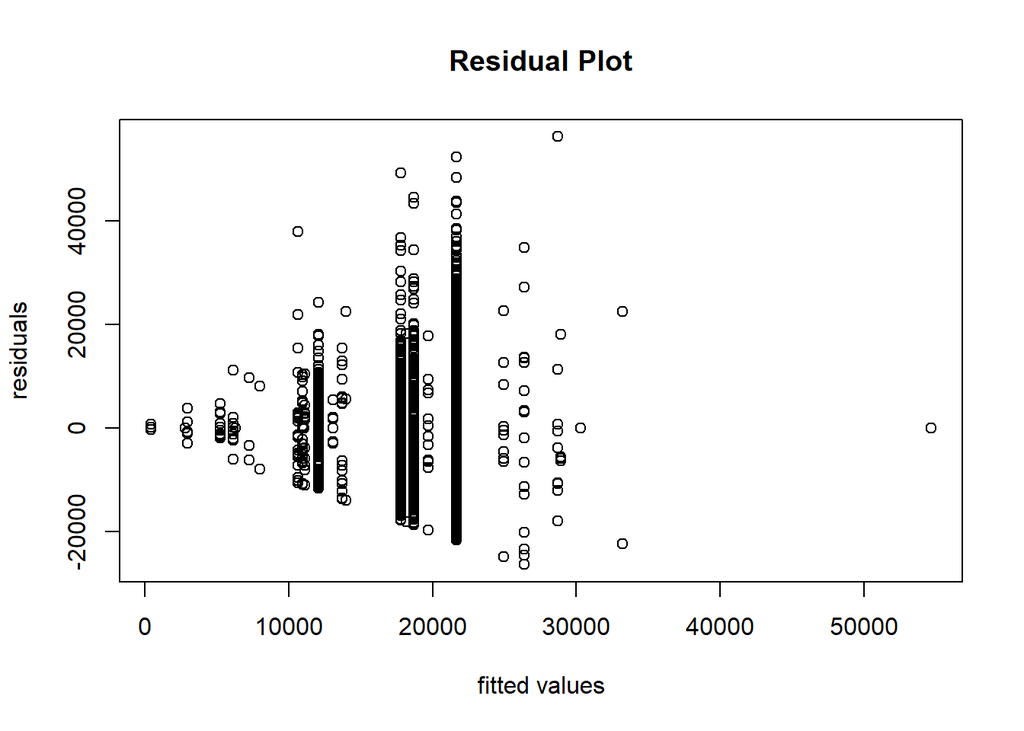

```r
# Code to perform residual analysis
plot(anovamodel$fitted, anovamodel$residuals, xlab="fitted values", ylab="residuals", main="Residual Plot")
```

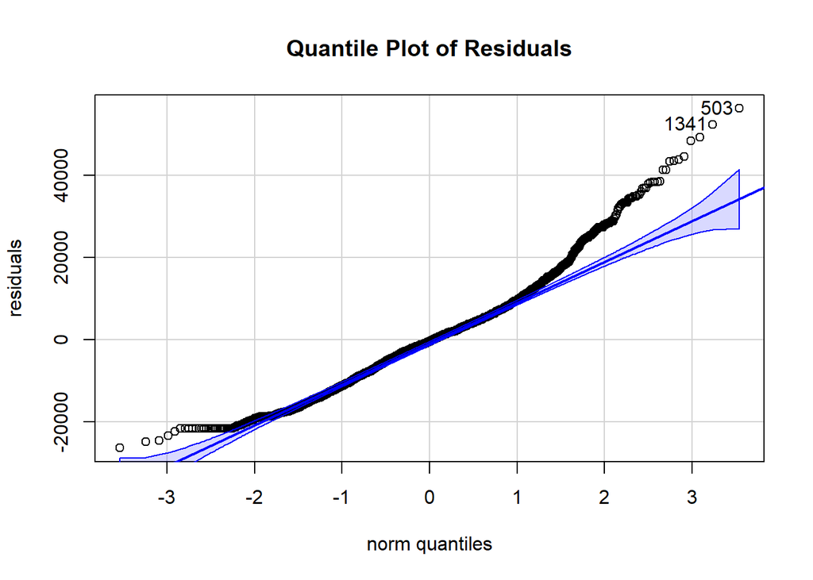

```
## [1]  503 1341
```

```r
qqPlot(anovamodel$residuals, ylab ="residuals", main ="Quantile Plot of Residuals")
```

### Question 5 - 4 pts

Based on your assessment of the assumptions (Question 4), is the ANOVA model (**anovamodel**) a good fit? If not, how can you try to improve the fit? Provide two recommendations and specify which problem(s) could be improved by each recommendation. *(Note: Do not apply your recommendations.)*

**Response to Question 5**:

**Assessment on GOF**: No we cannot say that this anovamodel is a good fit because it is violating 2 out of 3 assumptions.

**Recommendation 1 and problem(s)**: We can try a boxCox transformation and find the optimal lambda value to transform the response variable. This can probably help with the normality assumption.  
**Recommendation 2 and problem(s)**: We can also try transforming the predictor variable by some non-linear function like perhaps logarithmic, exponential etc.

### Question 6 - 5pts

Now consider the quantitative predicting variables ONLY: *year*, *homevalue*, *flooring*, *residents*.

Compute the correlation coefficient (*r*) between each quantitative variable and the response (*repaircost*).

1. Which predicting variable has the strongest linear relationship with the response? Which one has the weakest linear relationship?
2. Interpret the value of the strongest correlation coefficient in the context of the problem. Include strength (weak, moderate, strong) and direction (positive, negative). Note: You may consider > 0.3 and < 0.7 as moderate strength.

```r
# Code to calculate correlation...
cor(houses$repaircost, houses$year)
```

```
## [1] 0.4182736
```

```r
cor(houses$repaircost, houses$homevalue)
```

```
## [1] -0.4008382
```

```r
cor(houses$repaircost, houses$flooring)
```

```
## [1] -0.001881017
```

```r
cor(houses$repaircost, houses$residents)
```

```
## [1] -0.3754363
```

**Response to Question 6A**:

**Var with strongest correlation**: year

Create a scatter plot to describe the relationship between the house repair cost (*repaircost*) and the home value driven by the house (*homevalue*). Describe the general trend (direction and form).

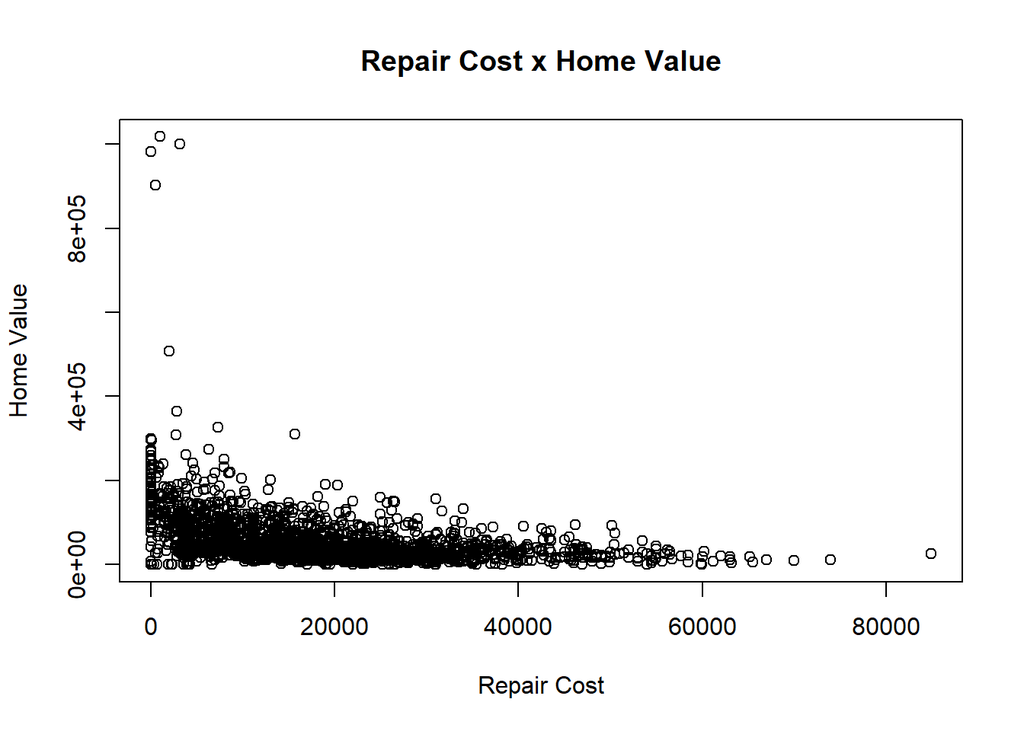

```r
# Code to create scatter plot...
plot(houses$repaircost, houses$homevalue, xlab="Repair Cost", ylab="Home Value", main="Repair Cost x Home Value")
```

### Question 8 - 4pts

Create a linear regression model, called **lm.full**, with *repaircost* as the response variable and with **ALL** remaining variables (quantitative and qualitative) as the predictors. Display the summary table for the model. *Note: Treat all variables as quantitative variables except for rooftype, and flood_status. Include an intercept.*

1. Is the model significant overall using an alpha of 0.01? Why/Why not?

```r
# Code to create model and display summary table
lm.full <- lm(repaircost ~., data=houses)

summary(lm.full)
```

```
##
## Call:
## lm(formula = repaircost ~ ., data = houses)
##
## Residuals:
##    Min     1Q Median     3Q    Max
## -43797  -5818  -1586   4371  54676
##
## Coefficients:
##                        Estimate Std. Error t value Pr(>|t|)
## (Intercept)          -1.525e+06  1.661e+05  -9.183  < 2e-16 ***
## rooftypebarrel       -2.976e+03  9.785e+03  -0.304   0.7610
## rooftypebell         -7.804e+03  9.796e+03  -0.797   0.4257
## rooftypebox          -4.131e+03  9.795e+03  -0.422   0.6732
## rooftypebutterfly    -1.178e+04  9.894e+03  -1.190   0.2340
## rooftypeclerestory   -7.960e+03  1.004e+04  -0.793   0.4278
## rooftypecombination  -1.285e+04  1.015e+04  -1.265   0.2058
## rooftypeconical      -4.988e+03  1.015e+04  -0.491   0.6233
## rooftypecrosshipped  -1.505e+04  1.019e+04  -1.478   0.1396
## rooftypecurved        3.720e+03  1.025e+04   0.363   0.7168
## rooftypedome         -1.489e+04  9.945e+03  -1.497   0.1345
## rooftypedormer        1.377e+03  1.026e+04   0.134   0.8932
## rooftypedropped      -2.013e+04  1.009e+04  -1.994   0.0462 *
## rooftypedutch        -8.757e+03  1.196e+04  -0.732   0.4643
## rooftypeflat         -1.427e+04  1.016e+04  -1.404   0.1605
## rooftypegable        -2.145e+04  1.073e+04  -2.000   0.0457 *
## rooftypegambrel      -2.550e+04  1.380e+04  -1.848   0.0647 .
## rooftypehexagonal    -6.636e+03  1.127e+04  -0.589   0.5559
## rooftypehip           2.800e+04  1.380e+04   2.028   0.0426 *
## rooftypejerkinhead    3.826e+02  1.093e+04   0.035   0.9721
## rooftypemansard       5.160e+03  1.196e+04   0.431   0.6663
## rooftypemonitor      -1.367e+04  9.804e+03  -1.394   0.1634
## rooftypemshaped       4.242e+02  1.199e+04   0.035   0.9718
## rooftypepyramid       1.502e+03  1.093e+04   0.137   0.8907
## rooftypesaltbox       4.138e+03  1.380e+04   0.300   0.7643
## rooftypesawtooth      2.634e+04  1.143e+04   2.305   0.0213 *
## rooftypeshed         -1.561e+04  1.380e+04  -1.131   0.2581
## rooftypevault         4.130e+03  1.007e+04   0.410   0.6818
## year                  7.664e+02  8.225e+01   9.318  < 2e-16 ***
## flood_statusno flood  7.092e+03  9.731e+02   7.288 4.21e-13 ***
## homevalue            -5.990e-02  6.530e-03  -9.173  < 2e-16 ***
## flooring             -5.143e+01  6.798e+01  -0.757   0.4494
## residents             6.961e+02  8.741e+02   0.796   0.4259
## ---
## Signif. codes:  0 '***' 0.001 '**' 0.01 '*' 0.05 '.' 0.1 ' ' 1
##
## Residual standard error: 9722 on 2466 degrees of freedom
## Multiple R-squared:  0.3644, Adjusted R-squared:  0.3562
## F-statistic: 44.19 on 32 and 2466 DF,  p-value: < 2.2e-16
```

**Response to Question 8A**:  
Yes the model is overall significant as the p-value is less than the significance level provided which is 0.01.

### Question 9 - 3pts

What is the estimated coefficient for *year* in **lm.full**? Provide a brief meaningful interpretation of the estimated regression coefficient for *year* in **lm.full**.

**Response to Question 9**:  
Coefficient of year = 7.664e+02  
This coefficient states that on average there will be a change of 7.664e+02 in the response variable with every 1 unit change in year given that all other predictors are kept constant.

### Question 10 - 4pts

What are the bounds for a **95%** confidence interval on the coefficient for *residents*? Using this confidence interval, is the coefficient for *residents* plausibly equal to zero at this confidence level, given all other predictors in the model? Explain.

```r
# Code to calculate 95% CI...
confint(lm.full, "residents", level=0.95)
```

```
##               2.5 %  97.5 %
## residents -1018.058 2410.17
```

**Response to Question 10**:  
The coefficient for residents from the summary = 696.1 The CI = (-1018.058, 2410.17) which contains 0 - This implies that the coefficient for residents can be ZERO at 95% confidence interval. But this is just one sided, we should analyse more by doing a partial F-test to figure out if the nested version of the model without residents is actually statistically significantly better.

### Question 11 - 4pts

Create a third model, called **lm.full2**, by adding an interactive term for home value driven per user (homevalue/residents) to **lm.full**. Display the summary table for this model.

1. Examine the summary tables for **lm.full2** and **lm.full**. Is there any significant change in the direction and/or statistical significance of the regression coefficients? If so, list one change.

```r
# Code to create lm.full2 and display summary table
houses$home_value_driven_per_user <- houses$homevalue/houses$residents

lm.full2 <- lm(repaircost ~., data=houses)

summary(lm.full2)
```

```
##
## Call:
## lm(formula = repaircost ~ ., data = houses)
##
## Residuals:
##    Min     1Q Median     3Q    Max
## -26080  -5219  -1436   3990  52070
##
## Coefficients:
##                              Estimate Std. Error t value Pr(>|t|)
## (Intercept)                -8.411e+05  1.671e+05  -5.035 5.13e-07 ***
## rooftypebarrel              1.904e+03  9.424e+03   0.202   0.8399
## rooftypebell               -2.922e+03  9.434e+03  -0.310   0.7568
## rooftypebox                 1.026e+03  9.434e+03   0.109   0.9134
## rooftypebutterfly          -7.274e+03  9.528e+03  -0.764   0.4452
## rooftypeclerestory         -3.153e+03  9.665e+03  -0.326   0.7443
## rooftypecombination        -6.943e+03  9.778e+03  -0.710   0.4778
## rooftypeconical            -1.063e+03  9.775e+03  -0.109   0.9134
## rooftypecrosshipped        -1.105e+04  9.807e+03  -1.127   0.2598
## rooftypecurved              9.818e+03  9.877e+03   0.994   0.3203
## rooftypedome               -1.076e+04  9.575e+03  -1.124   0.2610
## rooftypedormer              5.448e+03  9.878e+03   0.551   0.5814
## rooftypedropped            -1.441e+04  9.723e+03  -1.482   0.1386
## rooftypedutch              -2.849e+03  1.152e+04  -0.247   0.8047
## rooftypeflat               -8.042e+03  9.789e+03  -0.822   0.4114
## rooftypegable              -2.230e+04  1.032e+04  -2.160   0.0309 *
## rooftypegambrel            -2.181e+04  1.328e+04  -1.642   0.1008
## rooftypehexagonal          -1.097e+03  1.085e+04  -0.101   0.9195
## rooftypehip                 2.951e+04  1.328e+04   2.222   0.0264 *
## rooftypejerkinhead          5.454e+03  1.052e+04   0.518   0.6043
## rooftypemansard             8.810e+03  1.152e+04   0.765   0.4443
## rooftypemonitor            -8.587e+03  9.442e+03  -0.909   0.3632
## rooftypemshaped             5.271e+03  1.155e+04   0.457   0.6480
## rooftypepyramid             5.428e+03  1.052e+04   0.516   0.6060
## rooftypesaltbox             8.784e+03  1.328e+04   0.661   0.5084
## rooftypesawtooth           -1.062e+04  1.131e+04  -0.939   0.3478
## rooftypeshed               -1.167e+04  1.328e+04  -0.878   0.3798
## rooftypevault               8.228e+03  9.697e+03   0.849   0.3962
## year                        4.321e+02  8.265e+01   5.229 1.85e-07 ***
## flood_statusno flood        7.640e+03  9.373e+02   8.151 5.66e-16 ***
## homevalue                   1.013e-01  1.307e-02   7.745 1.38e-14 ***
## flooring                   -6.052e+01  6.543e+01  -0.925   0.3551
## residents                  -1.037e+04  1.152e+03  -9.002  < 2e-16 ***
## home_value_driven_per_user -2.651e-01  1.886e-02 -14.057  < 2e-16 ***
## ---
## Signif. codes:  0 '***' 0.001 '**' 0.01 '*' 0.05 '.' 0.1 ' ' 1
##
## Residual standard error: 9356 on 2465 degrees of freedom
## Multiple R-squared:  0.4116, Adjusted R-squared:  0.4037
## F-statistic: 52.25 on 33 and 2465 DF,  p-value: < 2.2e-16
```

**Response to Question 11A**:  
Yes we see that the direction for residents coefficient has reversed now and is now statistically significant.

### Question 12 - 4pts

Perform a Partial F-test on the new model (**lm.full2**) vs the previous model (**lm.full**), using $\alpha=0.05$.

1. State the Null and Alternative Hypothesis for this Partial F-test.
2. Do you *reject* or *fail to reject* the null hypothesis? Explain your answer using the output.
3. Based on these results, does the new variable (the interactive term for homevalue driven per user) add to the explanatory power of the model, given all other predictors are included? (Yes or No should suffice in conjunction w/ 12B)

```r
# Code for Partial F-Test...
anova(lm.full, lm.full2)
```

```
## Analysis of Variance Table
##
## Model 1: repaircost ~ rooftype + year + flood_status + homevalue + flooring +
##     residents
## Model 2: repaircost ~ rooftype + year + flood_status + homevalue + flooring +
##     residents + home_value_driven_per_user
##   Res.Df        RSS Df  Sum of Sq      F    Pr(>F)
## 1   2466 2.3307e+11
## 2   2465 2.1577e+11  1 1.7297e+10 197.61 < 2.2e-16 ***
## ---
## Signif. codes:  0 '***' 0.001 '**' 0.01 '*' 0.05 '.' 0.1 ' ' 1
```

**Response to Question 12A**:  
NULL - Models are statistically different -> Coefficients removed from the model are zero  
ALTERNATIVE - At least 1 of the removed coefficients is not zero.

### Question 13 - 5pts

Using **lm.full** model, what is the predicted *repaircost* and corresponding **90% prediction interval** for **no flood** **2016** **aframe** with **2** prior residents, flooring **1** and **10,000** home value? Provide an interpretation of your results.

*(Note: The data point has been provided. Ensure you are using lm.full not lm.full2)*

```r
# new observation...
newpt <- data.frame(rooftype='aframe', year=2016, flood_status="no flood",
                    residents=2, flooring= 1, homevalue=10000)

# Code for prediction interval...
predict(lm.full, newpt, interval="prediction", level=0.90)
```

```
##        fit      lwr      upr
## 1 27813.69 5104.815 50522.56
```

**The End.**